# Reproducible Report on COVID19 Data

P.Badilla

2022-10-08

## Introduction

For this project, the data sets used were downloaded from a GitHub repository [“JHU CSSE COVID-19 Data”](https://github.com/CSSEGISandData/COVID-19). The “time series” data sets in the repository `csse_covid_19_data > csse_covid_19_time_series` were used. These data set include information about confirmed cases and confirmed deaths for the U.S. and globally.

[Confirmed cases in the U.S.](https://github.com/CSSEGISandData/COVID-19/blob/master/csse_covid_19_data/csse_covid_19_time_series/time_series_covid19_confirmed_US.csv) : time_series_covid19_confirmed_US.csv

[Confirmed deaths in the U.S.](https://github.com/CSSEGISandData/COVID-19/blob/master/csse_covid_19_data/csse_covid_19_time_series/time_series_covid19_deaths_US.csv): time_series_covid19_deaths_US.csv

[Confirmed global cases](https://github.com/CSSEGISandData/COVID-19/blob/master/csse_covid_19_data/csse_covid_19_time_series/time_series_covid19_confirmed_global.csv) : time_series_covid19_confirmed_global.csv

[Confirmed global deaths](https://github.com/CSSEGISandData/COVID-19/blob/master/csse_covid_19_data/csse_covid_19_time_series/time_series_covid19_deaths_global.csv) : time_series_covid19_deaths_global.csv

I will also need a population data file for the global cases and deaths. [Global Population](https://github.com/CSSEGISandData/COVID-19/blob/master/csse_covid_19_data/UID_ISO_FIPS_LookUp_Table.csv) : UID_ISO_FIPS_LookUp_Table.csv

After review these data sets, a few questions of interest were:

1. When did each country begin to have confirmed COVID-19 cases?
2. When did each state in the U.S. begin to have confirmed COVID-19 cases?
3. Which months had the highest number of confirmed cases and confirmed deaths for each country?

## Importing Dataset and Initial Cleaning

Import the appropriate libraries. For this project, we will be using `tidyverse` and `lubridate`

To Read in Data, use `variable_name <- read_csv("FILE URL")`

For this project, there are multiple files to import. I’ll create a variable for each data set and read the csv file into that variable.

`US_cases <- read_csv(https://github.com/CSSEGISandData/COVID-19/blob/master/csse_covid_19_data/csse_covid_19_time_series/time_series_covid19_confirmed_US.csv)`

`US_deaths <- read_csv(https://github.com/CSSEGISandData/COVID-19/blob/master/csse_covid_19_data/csse_covid_19_time_series/time_series_covid19_deaths_US.csv)`

`global_cases <- read_csv(https://github.com/CSSEGISandData/COVID-19/blob/master/csse_covid_19_data/csse_covid_19_time_series/time_series_covid19_confirmed_global.csv)`

`global_deaths <- read_csv(https://github.com/CSSEGISandData/COVID-19/blob/master/csse_covid_19_data/csse_covid_19_time_series/time_series_covid19_deaths_global.csv)`

To ensure the data was imported correctly, it is important to preview it and understand its contents.To preview the data set, call the variable name. For example:

`US_cases`

Or, you can see the data table by using the `View` function. For example:

`View(US_cases)`

```r
library(tidyverse)
library(lubridate)
US_cases <- read_csv("https://raw.githubusercontent.com/CSSEGISandData/COVID-19/master/csse_covid_19_data/csse_covid_19_time_series/time_series_covid19_confirmed_US.csv")
US_deaths <- read_csv("https://raw.githubusercontent.com/CSSEGISandData/COVID-19/master/csse_covid_19_data/csse_covid_19_time_series/time_series_covid19_deaths_US.csv")
global_cases <- read_csv("https://raw.githubusercontent.com/CSSEGISandData/COVID-19/master/csse_covid_19_data/csse_covid_19_time_series/time_series_covid19_confirmed_global.csv")
global_deaths <- read_csv("https://raw.githubusercontent.com/CSSEGISandData/COVID-19/master/csse_covid_19_data/csse_covid_19_time_series/time_series_covid19_deaths_global.csv")
global_population <- read_csv("https://raw.githubusercontent.com/CSSEGISandData/COVID-19/master/csse_covid_19_data/UID_ISO_FIPS_LookUp_Table.csv")
```

For easier data management, we can remove columns that won’t be needed or don’t provide useful information. Print the names of the variables with the `print()` function. Decide which columns you would like to remove, and use `select(-c())` to specify which columns to *not* select when creating a “filtered” data frame for each variable.

In this data set, most of the columns are the dates for which there are data about each state or country. Transposing each date column to be a row will make the data easier to work with and understand. I will also combine the cases and deaths data frames into one for US data and one for global data. Converting columns to appropriate types (like a `date` type instead of a `char` type for dates) will be helpful for data manipulation later on also. Lastly, modify the data frames so that both data frames have as many similar columns as possible.

1. Use the `pivot_longer` function to transpose columns into rows
2. Use the `full_join` function to combine data frames based on all columns that are identical in each data frame
3. Use the `mutate` function to convert a character type column into a date type column
4. Modify the global data frame to have the same format as the US data frame. This requires a union between the “Province_State, Country_Region” into a new column “Combined_key” as well as the addition of a “population” column.

To add the “Population column to the global data frame, I will need to import the population data. Luckily, the directory used above contains a csv file with the population information. This can be found here

```r
print(colnames(US_cases))
US_cases <- US_cases %>%
    pivot_longer(cols= -c('Province_State', 'Country_Region', 'UID', 'iso2', 'iso3', 'code3', 'FIPS', 'Lat', 'Long_', 'Admin2', 'Combined_Key'),
        names_to = "date",
        values_to = "cases") %>%
    select(-c(UID, iso2, iso3, code3, FIPS, Lat, Long_))


print(colnames(US_deaths))
US_deaths <- US_deaths %>%
    pivot_longer(cols= -c('Province_State', 'Country_Region', UID, iso2, iso3, code3, FIPS, Lat, Long_, Admin2, Combined_Key, Population),
        names_to = "date",
        values_to = "deaths") %>%
    select(-c(UID, iso2, iso3, code3, FIPS, Lat, Long_))

US_combined <- US_cases %>% full_join(US_deaths) %>%
  mutate(date = mdy(date))
```

[output not shown]

```r
print(colnames(global_cases))
global_cases <- global_cases %>%
    pivot_longer(cols= -c('Province/State', 'Country/Region', Lat, Long),
        names_to = "date",
        values_to = "cases") %>%
    select(-c(Lat,Long))


print(colnames(global_deaths))
global_deaths <- global_deaths %>%
    pivot_longer(cols= -c('Province/State', 'Country/Region', Lat, Long),
        names_to = "date",
        values_to = "deaths") %>%
    select(-c(Lat,Long))


global_combined <- global_cases %>% full_join(global_deaths) %>%
  rename(Country_Region = 'Country/Region', Province_State = 'Province/State') %>%
  mutate(date = mdy(date))
global_combined <- global_combined %>%
  unite("Combined_key",
        c(Province_State, Country_Region),
        sep = ", ",
        na.rm = TRUE,
        remove = FALSE)

global_population <- global_population %>%
  select(-c(Admin2,Lat,Long_,Combined_Key,iso2,iso3,code3))

global <- global_combined %>%
  left_join(global_population, by = c("Province_State", "Country_Region")) %>%
  select(-c(UID,FIPS)) %>%
  select(Province_State,Country_Region, date, cases, deaths, Population,Combined_key)

#global <- global %>% mutate(date = mdy(date))
```

### Summary of data and Filtering:

To see if data frames are as expected, view each frame. Then, call the `summary()` function to review a brief summary of each data frame.

`summary(US_combined)` `summary(global)`

```r
summary(US_combined)
```

```
##     Admin2          Province_State     Country_Region     Combined_Key
##  Length:3311922     Length:3311922     Length:3311922     Length:3311922
##  Class :character   Class :character   Class :character   Class :character
##  Mode  :character   Mode  :character   Mode  :character   Mode  :character
##
##
##
##       date                cases           Population           deaths
##  Min.   :2020-01-22   Min.   :  -3073   Min.   :       0   Min.   :  -82.0
##  1st Qu.:2020-09-25   1st Qu.:    213   1st Qu.:    9917   1st Qu.:    2.0
##  Median :2021-05-31   Median :   1782   Median :   24892   Median :   30.0
##  Mean   :2021-05-31   Mean   :  11649   Mean   :   99604   Mean   :  165.4
##  3rd Qu.:2022-02-03   3rd Qu.:   6609   3rd Qu.:   64979   3rd Qu.:  105.0
##  Max.   :2022-10-08   Max.   :3464157   Max.   :10039107   Max.   :33740.0
```

```r
summary(global)
```

```
##  Province_State     Country_Region          date                cases
##  Length:286399      Length:286399      Min.   :2020-01-22   Min.   :       0
##  Class :character   Class :character   1st Qu.:2020-09-25   1st Qu.:     408
##  Mode  :character   Mode  :character   Median :2021-05-31   Median :    9935
##                                        Mean   :2021-05-31   Mean   :  759536
##                                        3rd Qu.:2022-02-03   3rd Qu.:  169253
##                                        Max.   :2022-10-08   Max.   :96694214
##
##      deaths          Population        Combined_key
##  Min.   :      0   Min.   :6.700e+01   Length:286399
##  1st Qu.:      2   1st Qu.:5.790e+05   Class :character
##  Median :    113   Median :6.574e+06   Mode  :character
##  Mean   :  11870   Mean   :2.769e+07
##  3rd Qu.:   2444   3rd Qu.:2.642e+07
##  Max.   :1062560   Max.   :1.380e+09
##                    NA's   :8919
```

```r
US_combined <- US_combined %>% filter(cases>0)
global <- global %>% filter(cases>0)
```

## Data Analysis: Visualizing, Analyzing, and Modeling the Data

Revisiting the questions of interest:

```r
global_by_country <- global %>%
  group_by(Province_State, Country_Region, date) %>%
  summarise(cases = sum(cases), deaths = sum(deaths), Population = sum(Population))
US_by_state <- US_combined %>%
  group_by(Province_State, date) %>%
  summarise(cases = sum(cases), deaths = sum(deaths), Population = sum(Population))
```

### Visualizing data:

question 1: create a new frame that is sorted by date, and plot the first date for each country.

```r
global_first_case_date <- global_by_country %>% arrange(date)
country_first_date <- global_first_case_date[match(unique(global_first_case_date$Country_Region), global_first_case_date$Country_Region ),]
```

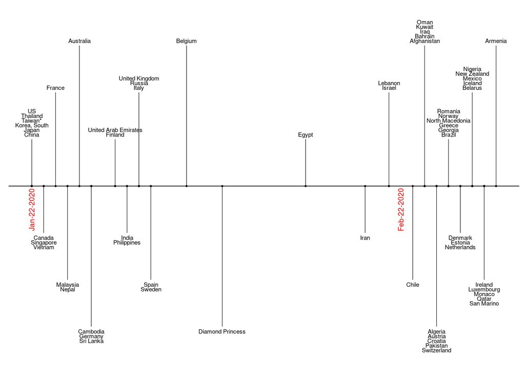

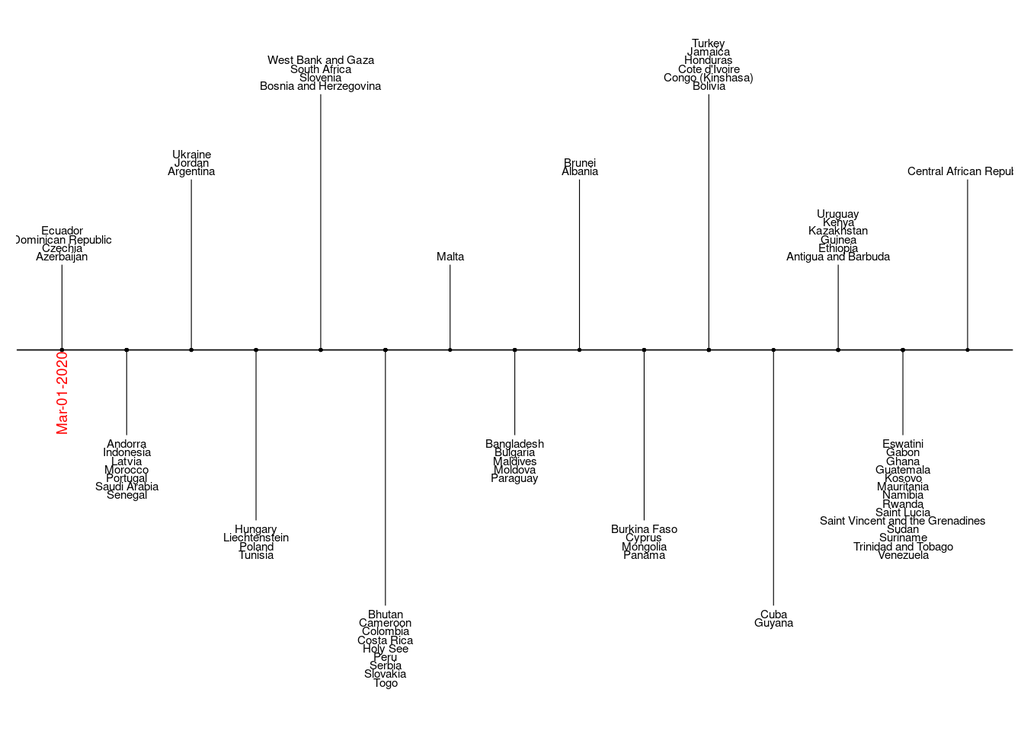

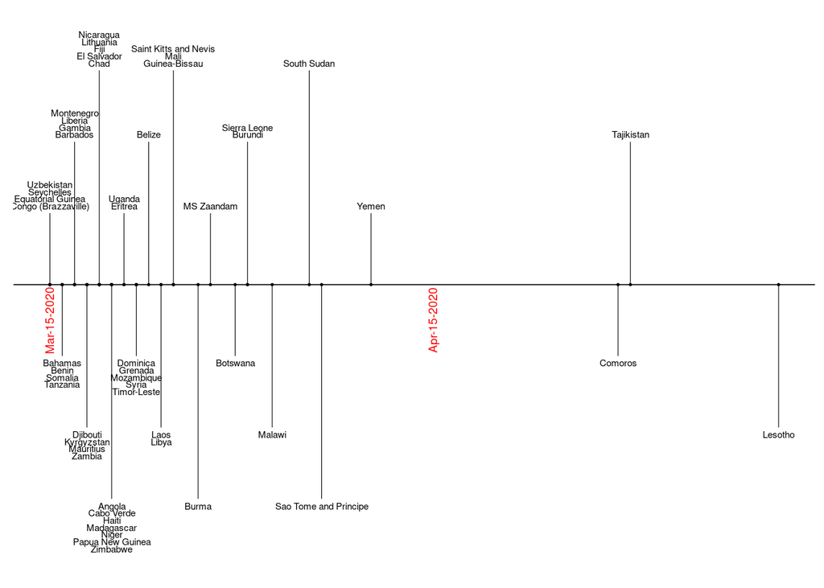

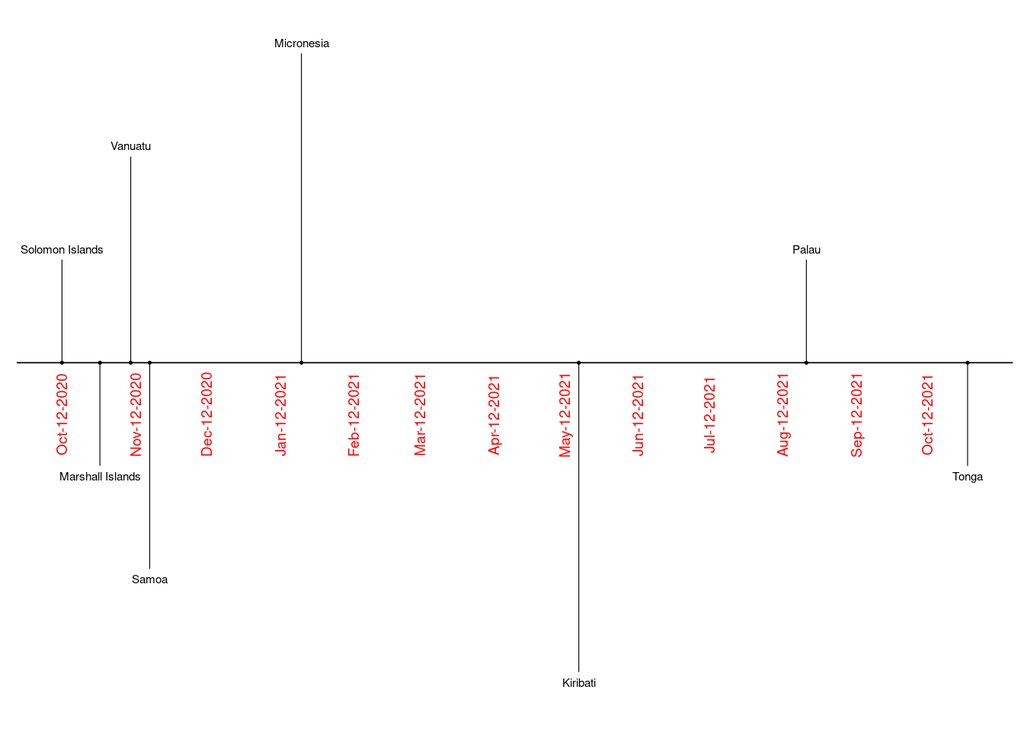

question 2: do same as above but for US data

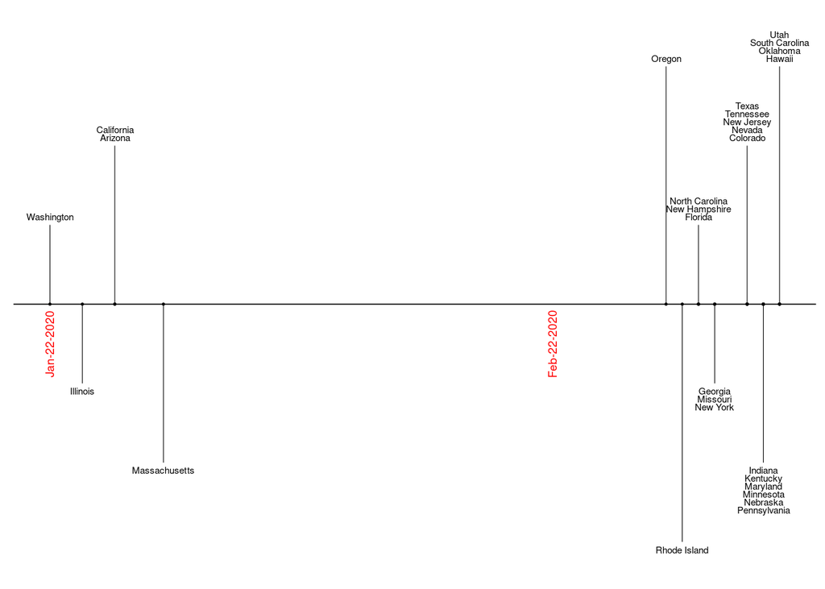

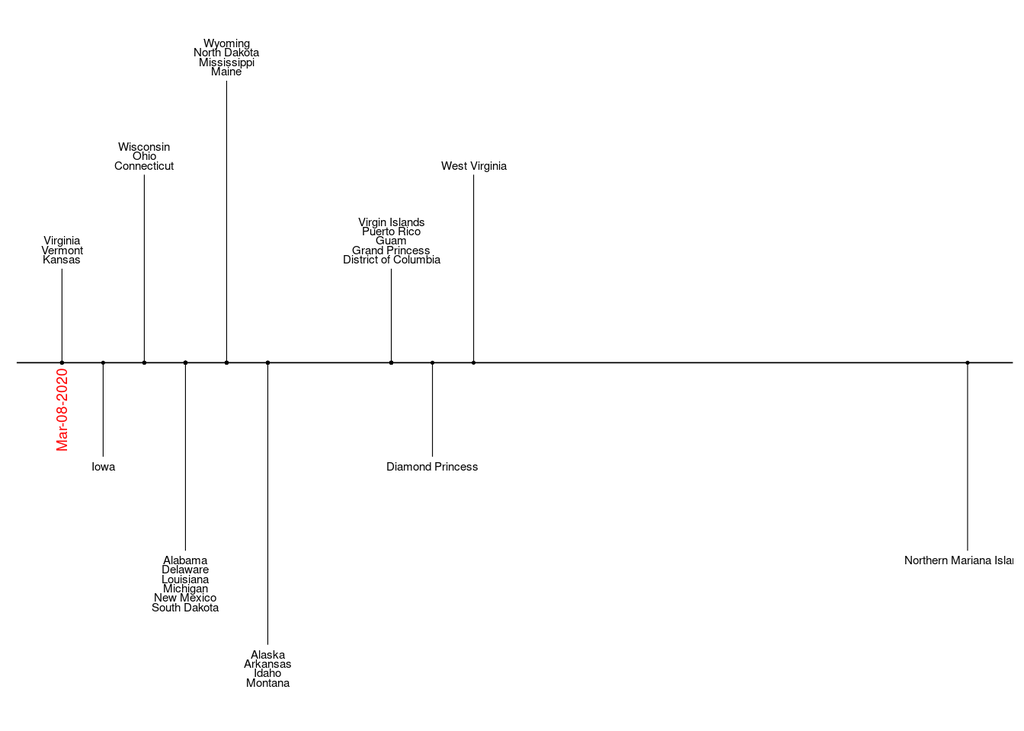

```r
global_cases_CountryDate <- global %>%
  group_by(Country_Region, date) %>%
  summarize(cases = sum(cases), deaths = sum(deaths), Population = sum(Population)) %>%
  mutate(deaths_per_million = deaths * 1000000 / Population) %>%
  mutate(cases_per_million = cases * 1000000 / Population)
```

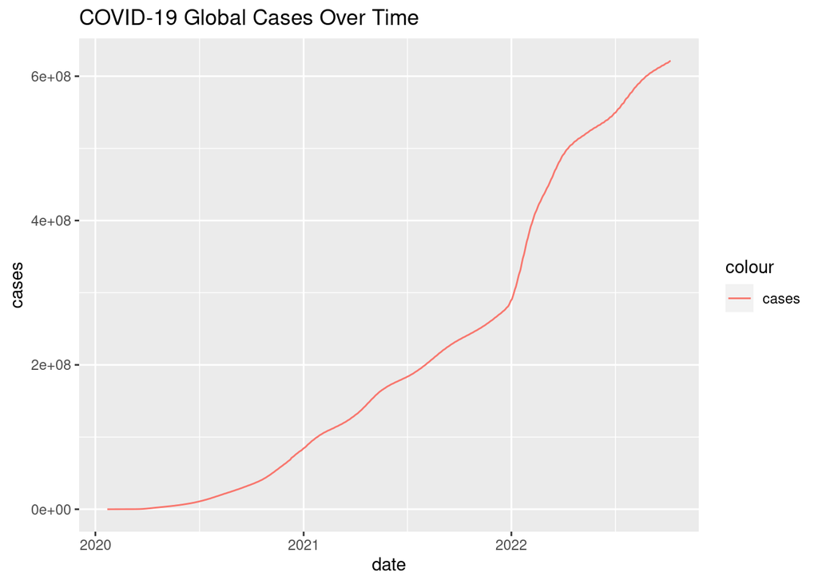

```r
global_cases_by_date <- global %>%
  group_by(date) %>%
  summarize(cases = sum(cases), deaths = sum(deaths))


g1 <- global_cases_by_date %>%
    ggplot(aes(x=date)) +
    geom_line(aes(y = cases, color = "cases")) +
    labs(title = "COVID-19 Global Cases Over Time", y = "cases")

g2 <- global_cases_by_date %>%
    ggplot(aes(x=date)) +
    geom_line(aes(y=deaths, color = "deaths"))+
    labs(title = "COVID-19 Global Deaths Over Time", y = "deaths")

g1
```

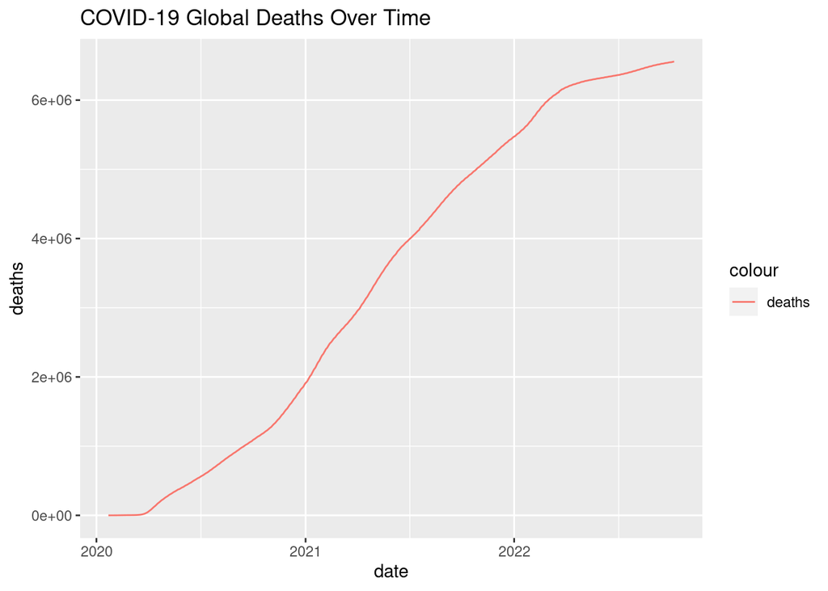

```r
g2
```

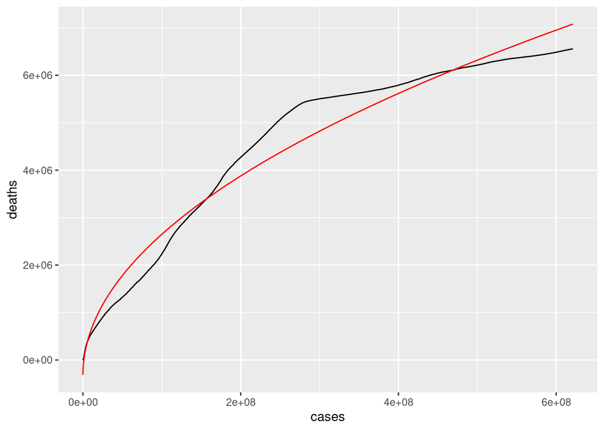

```r
mod <- lm(deaths ~ I(cases^0.5), data = global_cases_by_date)
#mod <- lm(deaths ~ cases, data = global_cases_by_date)
ggplot(global_cases_by_date, aes(x=cases, y=deaths)) +
  geom_line() +
  geom_line(aes(x=cases, y=fitted(mod)), color = "red")
```

```r
model <- global_cases_by_date %>% mutate(pred = predict(mod))
summary(model)
```

```
##       date                cases               deaths             pred
##  Min.   :2020-01-22   Min.   :      557   Min.   :     17   Min.   :-312168
##  1st Qu.:2020-09-25   1st Qu.: 32775314   1st Qu.:1056970   1st Qu.:1379838
##  Median :2021-05-31   Median :171243093   Median :3693126   Median :3564388
##  Mean   :2021-05-31   Mean   :219505998   Mean   :3430474   Mean   :3430474
##  3rd Qu.:2022-02-02   3rd Qu.:387027348   3rd Qu.:5738073   3rd Qu.:5519221
##  Max.   :2022-10-08   Max.   :621241564   Max.   :6556879   Max.   :7077795
```

### Sources of Bias

Sources of bias in this data set could include:

- Accuracy in when each country reported their first confirmed case
- Which countries/regions were more likely to test for COVID in the early stages of the pandemic (i.e. some countries did not feel they were at risk and didn’t test those who entered from traveling abroad, which could have affected how early they got a confirmed case)
- How many cases were confirmed and reported during the beginning of COVID considering how difficult it was to get a test at the time

### Conclusion

In conclusion, this data analysis provided insight to a timeline of when each country began to experience confirmed COVID cases and how each state in the US compares on this time line as well.